# **(BloomAlert - AgroSpace)** Intern Test | Marzo 2022

**Autor:** *Tomás Saldivia Astudillo*

Este notebook forma parte del desarrollo del intern test de BloomAlert y AgroSpace. A través de el, se puede presentar de manera concisa y clara la funcionalidad del código implementado. Dentro de las habilidades que se busca evaluar se encuentran:

1. Manipulación de datos satelitales y capas vectoriales
2. Análisis y visualización de datos
3. Interpretación de resultados
4. Creación de cartografías
5. Desarrollo informático general

### Contexto

El eje central de este trabajo es analizar una serie temporal de datos satelitales. Por un lado, se busca extraer información asociada a capas vectoriales y geometrías que estas puedan definir (e.g. polígonos), esto contenido en archivos *.geojson* o *.shapefiles*. Por otro lado, los datos satelitales de interés, en este caso el índice NDVI, se encuentran almacenados en archivos raster (GTIFF con la extensión .tif).

Lo anterior se entiende bajo el área de la geomática, ciencia que estudia tanto capas vectoriales com rasters, y busca tomar decisiones en base a la información extraída de estos.

### Implementación

El código ha sido desarrollado de manera local y se ha respaldado para su acceso en [Github](https://github.com/Tom0497/BAInternTest).

```python
!git clone https://github.com/Tom0497/BAInternTest.git
%cd /content/BAInternTest/
```

```
Cloning into 'BAInternTest'...
remote: Enumerating objects: 73, done.
remote: Counting objects: 100% (73/73), done.
remote: Compressing objects: 100% (64/64), done.
remote: Total 73 (delta 7), reused 68 (delta 5), pack-reused 0
Unpacking objects: 100% (73/73), done.
/content/BAInternTest
```

Es imperativo agregar el directorio raíz del proyecto a la variable de entorno de python, de esta manera, las exportaciones de los distintos modulos funcionaran de la manera correcta. Se puede tomar la siguiente celda, que imprime el current working directory, y luego modificar la variable de entorno `PYTHONPATH` para que la contenga.

```python
%cd /content/BAInternTest/
!echo $PYTHONPATH
```

```
/content/BAInternTest
/env/python
```

```python
import os

os.environ['PYTHONPATH'] += ":/content/BAInternTest"
!echo $PYTHONPATH
```

```
/env/python:/content/BAInternTest
```

#### Requerimientos

Para la correcta ejecución del código y sus funcionalidades, se requiere instalar una serie de librerías para tratar con datos satelitales, además de librerías de calculo matricial como Numpy, Pandas y para graficar MatPlotLib. Estas y otras requeridas se especifican en el archivo `requirements.txt`.

```python
!pip3 install -qr requirements.txt
!pip3 install --upgrade matplotlib
```

[output not shown]

### 2. Extraer las series temporales según el .geojson o .kml

Se utiliza la librería `rasterstats`, la cual permite obtener diversas métricas de interés de un raster utilizando las geometrías definidas en el archivo *.geojson*.

En específico, para cada polígono definido, se toman los valores de los pixeles contenidos en él en el raster. Con esos valores, se procede a computar una o más estadísticas de interés que representen en un valor el estado de cierto potrero en un mes.

En general, un buen valor representante de un sector corresponde al promedio de valores, y en adelante se utilizará este estadístico en la mayoría de los casos, pero se remarca que `rasterstats` puede computar muchas otras métricas (ver su documentación).

A continuación se muestra la serie de tiempo construida para cada potrero, tomando como métrica representativa el promedio de los valores de cada raster por mes según los sectores definidos. Se ha dejado como índice del `DataFrame` el mes que representa al dato.

```python
from src.raster.rastertimeseries import check_timeseries_exist, construct_time_series, RasterTimeSeries

test_statistic = 'mean'
if not check_timeseries_exist(test_statistic):
  construct_time_series([test_statistic])
  print(f"La serie de tiempo {test_statistic} se ha creado")

rtseries = RasterTimeSeries(test_statistic)
series_df = rtseries.dataframe

series_df.head()
```

|  | Punta estero | Laurel | Patagua | Lado estero | Maiz 2 | Maiz 1 | Pero a | Los bolos a | El pero b | Los bolos b | Las piedras | Peña a | Peña b | Brazo Muerto | La isla |
| --- | --- | --- | --- | --- | --- | --- | --- | --- | --- | --- | --- | --- | --- | --- | --- |
| 2019-10-21 | 0.641358 | 0.647575 | 0.690170 | 0.734351 | 0.726001 | 0.638936 | 0.496588 | 0.690599 | 0.562863 | 0.780764 | 0.734801 | 0.714543 | 0.800662 | 0.684257 | 0.782824 |
| 2019-10-31 | 0.719605 | 0.798889 | 0.794977 | 0.784194 | 0.781610 | 0.665693 | 0.723406 | 0.465127 | 0.489962 | 0.519891 | 0.401119 | NaN | 0.329810 | 0.424370 | 0.600369 |
| 2019-11-10 | 0.784033 | 0.812444 | 0.815664 | 0.805742 | 0.589677 | 0.737670 | 0.732758 | 0.763999 | 0.708306 | 0.705692 | 0.634243 | 0.805083 | 0.770895 | 0.750761 | 0.786868 |
| 2019-11-20 | 0.724670 | 0.516553 | 0.480540 | 0.460237 | 0.791700 | 0.779611 | 0.796289 | 0.740096 | 0.805506 | 0.793545 | 0.726219 | 0.750297 | 0.720744 | 0.764323 | 0.698542 |
| 2019-11-25 | 0.580063 | 0.699810 | 0.705191 | 0.701698 | 0.657617 | 0.544042 | 0.751046 | 0.606257 | 0.809067 | 0.738515 | 0.619167 | 0.748912 | 0.768950 | 0.693307 | 0.753822 |

### 3. Calcular estadísticas descriptivas, promedios, desviaciones estándar y intercuartiles para cada potrero

Considerando las series de tiempo antes mostradas, al ser estas funciones que representan fenomenos en el tiempo, se pueden calcular métricas estadísticas respecto a las observaciones de una variable (NDVI) cuya función no se conoce.

A continuación se muestra el computo de tres métricas, el promedio, la desviación estándar y el rango intercuantílico, siendo la primera una medida de concentración y las otras dos medidas de dispersión.

```python
from src.raster.rastertimeseries import check_timeseries_exist, construct_time_series, RasterTimeSeries
from textwrap import dedent

test_statistic = 'mean'
if not check_timeseries_exist(test_statistic):
  construct_time_series([test_statistic])
  print(f"La serie de tiempo {test_statistic} se ha creado")

rtseries = RasterTimeSeries(test_statistic)
rtseries_stats = rtseries.compute_stats()

print("Métricas asociadas a NDVI promedio por potrero por mes.")
for potrero in rtseries_stats:
  mean, std, interquantile = rtseries_stats[potrero]
  print(dedent(f"""
  Métricas para el potrero: {potrero}
    promedio     --> {mean:.4f}
    desviación   --> {std:.4f}
    intercuantil --> {interquantile:.4f}
  """))
```

```
Métricas asociadas a NDVI promedio por potrero por mes.

Métricas para el potrero: Punta estero
  promedio     --> 0.6795
  desviación   --> 0.1237
  intercuantil --> 0.1299


Métricas para el potrero: Laurel
  promedio     --> 0.6921
  desviación   --> 0.1255
  intercuantil --> 0.1257


Métricas para el potrero: Patagua
  promedio     --> 0.6990
  desviación   --> 0.1226
  intercuantil --> 0.1034


Métricas para el potrero: Lado estero
  promedio     --> 0.6742
  desviación   --> 0.1293
  intercuantil --> 0.1253


Métricas para el potrero: Maiz 2
  promedio     --> 0.6903
  desviación   --> 0.1264
  intercuantil --> 0.1452


Métricas para el potrero: Maiz 1
  promedio     --> 0.5884
  desviación   --> 0.2150
  intercuantil --> 0.2578


Métricas para el potrero: Pero a
  promedio     --> 0.6745
```

[output cut: 35 more lines]

```
  promedio     --> 0.6978
  desviación   --> 0.1290
  intercuantil --> 0.1319


Métricas para el potrero: Brazo Muerto
  promedio     --> 0.6748
  desviación   --> 0.1136
  intercuantil --> 0.1394


Métricas para el potrero: La isla
  promedio     --> 0.6683
  desviación   --> 0.1230
  intercuantil --> 0.1705
```

### 4. Graficar el índice NDVI para 2 fechas y determinar que potrero es el más productivo

El NDVI, o *normalized difference vegetation index*, corresponde a un índice que en teoría vive en el rango [-1, 1], pero que generalmente se encuentra en el rango [0, 1]. Se miden las longitudes de onda reflejadas por el terreno (suelo, agua, plantaciones, etc), considerando como de interés para el cálculo las visibles rojas (625–750 nm approx), y las del rango no visible cercano a infrarojo (NIR near infrared) en el rango 700-1100 nm approx.

En términos simples, NDVI mide que tan verde es una planta, su contenido de clorofila, esto dado que la clorofila absorve la luz visible en el rango 400-700 nm, por lo que a mayor clorofila, mayor será el NDVI y más verde la planta. Esto implica que NDVI puede usarse como un indicador de la salud de la planta, su producción o algún otro factor relevante que pueda relacionarse con el verdor de la planta.

```python
from src.raster.rastertimeseries import check_timeseries_exist, construct_time_series, RasterTimeSeries
from textwrap import dedent

test_statistic = 'mean'
if not check_timeseries_exist(test_statistic):
  construct_time_series([test_statistic])
  print(f"La serie de tiempo {test_statistic} se ha creado")

rtseries = RasterTimeSeries(test_statistic)

print("Opción --> Mes")
for opt, date in rtseries.datetimes:
  print(dedent(f"""{opt} --> {date}"""))
```

```
Opción --> Mes
0 --> 2019-10-21
1 --> 2019-10-31
2 --> 2019-11-10
3 --> 2019-11-20
4 --> 2019-11-25
5 --> 2019-12-05
6 --> 2019-12-20
7 --> 2019-12-30
8 --> 2020-01-04
9 --> 2020-01-19
10 --> 2020-01-24
11 --> 2020-01-29
12 --> 2020-02-08
13 --> 2020-02-13
```

[output cut: 28 more lines]

En la celda anterior se muestran los meses para los cuales hay datos reportados, para comparar dos o mas meses se debe ejecutar la siguiente celda pasando como argumento una lista con los indices que representan los meses a observar.

En el grafico de barras se han incluído los valores para comparaciones más exactas. Observando la fecha 2019-10-21, el mayor NDVI promedio es para el potrero **Peña b** seguido de cerca de **La isla**, lo que es un indicador que las plantas de esos potreros tiene mejor salud y, por tanto, se podría en primera instancia argumentar que en esa fecha son los potreros más productivos.

Para la fecha 2019-11-20, el máximo está en **El pero b** seguido por **Pero a**, luego, por el mismo argumento anterior, para esa fecha específica, estos potreros son los más productivos.

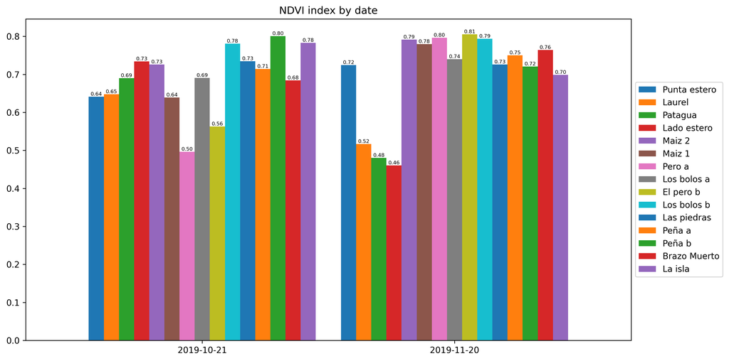

```python
rtseries.barplot_by_datetimes([0, 3]);
```

### 5. Generar una cartografía con leyenda y escala espacial.

A continuación se muestra el dibujo de los sectores delimitados por las geometrías del archivo *.geojson* sobre un mapa de la zona representada. Se observa que esta bordea al río Calle-Calle en lo que serían las afueras de la ciudad de Valdivia. Para identificar más fácil cada potrero, se agrega una leyenda y se escribe además sobre cada uno `Sector-ID` según define el archivo *.geojson*.

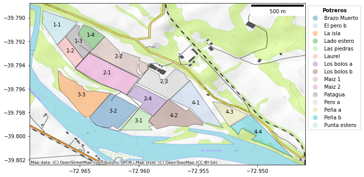

```
(<Figure size 720x432 with 1 Axes>, <AxesSubplot:>)
```

```python
from src.raster.rasterhandler import RasterHandler
import definitions

rh = RasterHandler(definitions.RASTER_DIR, definitions.VECTORS_DIR / 'agrospace_piloto.geojson')
rh.plot_over_map();
```

### 6. Generar una serie temporal de cada potrero.

Se grafican las series temporales creadas en el paso 2 y que se encuentran almacenadas en un CSV. Los datos corresponden al NDVI promedio por potrero en cada fecha reportada. Se puede observar la evolución de la métrica, como también procesos períodicos de caída, que pensando en plantaciones, podría hacer referencia a períodos de cosecha donde claramente el indice NDVI disminuye.

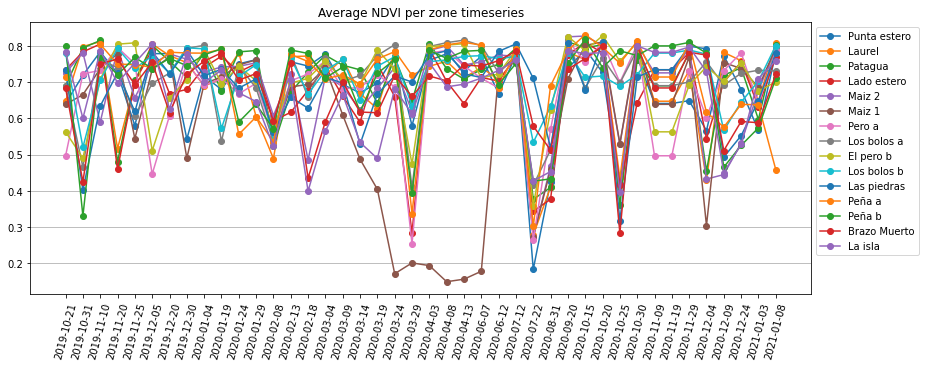

```python
from src.raster.rastertimeseries import check_timeseries_exist, construct_time_series, RasterTimeSeries
from textwrap import dedent

import numpy as np
import matplotlib.pyplot as plt

test_statistic = 'mean'
if not check_timeseries_exist(test_statistic):
  construct_time_series([test_statistic])
  print(f"La serie de tiempo {test_statistic} se ha creado")

rtseries = RasterTimeSeries(test_statistic)
series_df = rtseries.dataframe

fig, ax = plt.subplots(figsize=(14, 5))
series_df.plot(ax=ax, marker='o')
datetimes = series_df.index.to_list()

ax.grid(axis='y')
ax.set_xticks(np.arange(len(datetimes)), datetimes)
ax.tick_params(axis='x', labelrotation=75)
ax.legend(loc='upper left', bbox_to_anchor=(1, 1))
ax.set_title('Average NDVI per zone timeseries');
```